# Predicting the Price of Used Cars - Data Analysis Project - Abner Nole

In this project, i will use the dataset from kaggle, the links is :https://www.kaggle.com/datasets/austinreese/craigslist-carstrucks-data. And to be able to predict used cars market value can help both buyers and sellers. There are lots of individuals who are interested in the used car market because they wanted to sell their car or buy a used car.

For predict i will divided the project Preprocessing , EDA , Treatment of outliers , Feature Selection, Model development like Linear Regression,Random Forest Regressor and Gbt Regressor Model. At the end will conclude what model is the best for our dataset.

# Importing Libraries

```python
import numpy as np
import pandas as pd
import matplotlib.pyplot as plt
import seaborn as sns
from sklearn.metrics import mean_squared_error
from sklearn.metrics import r2_score

import warnings
warnings.simplefilter(action='ignore', category=FutureWarning)
```

# Loading the data

```python
df = pd.read_csv('vehicles.csv')
df.head()
```

|  | id | url | region | region_url | price | year | manufacturer | model | condition | cylinders | ... | size | type | paint_color | image_url | description | county | state | lat | long | posting_date |
| --- | --- | --- | --- | --- | --- | --- | --- | --- | --- | --- | --- | --- | --- | --- | --- | --- | --- | --- | --- | --- | --- |
| 0 | 7222695916 | https://prescott.craigslist.org/cto/d/prescott... | prescott | https://prescott.craigslist.org | 6000 | NaN | NaN | NaN | NaN | NaN | ... | NaN | NaN | NaN | NaN | NaN | NaN | az | NaN | NaN | NaN |
| 1 | 7218891961 | https://fayar.craigslist.org/ctd/d/bentonville... | fayetteville | https://fayar.craigslist.org | 11900 | NaN | NaN | NaN | NaN | NaN | ... | NaN | NaN | NaN | NaN | NaN | NaN | ar | NaN | NaN | NaN |
| 2 | 7221797935 | https://keys.craigslist.org/cto/d/summerland-k... | florida keys | https://keys.craigslist.org | 21000 | NaN | NaN | NaN | NaN | NaN | ... | NaN | NaN | NaN | NaN | NaN | NaN | fl | NaN | NaN | NaN |
| 3 | 7222270760 | https://worcester.craigslist.org/cto/d/west-br... | worcester / central MA | https://worcester.craigslist.org | 1500 | NaN | NaN | NaN | NaN | NaN | ... | NaN | NaN | NaN | NaN | NaN | NaN | ma | NaN | NaN | NaN |
| 4 | 7210384030 | https://greensboro.craigslist.org/cto/d/trinit... | greensboro | https://greensboro.craigslist.org | 4900 | NaN | NaN | NaN | NaN | NaN | ... | NaN | NaN | NaN | NaN | NaN | NaN | nc | NaN | NaN | NaN |

5 rows × 26 columns

# Preprocessing the data

### Exploring the descriptive statistics of the variables

```python
df.describe()
```

|  | id | price | year | odometer | county | lat | long |
| --- | --- | --- | --- | --- | --- | --- | --- |
| count | 4.268800e+05 | 4.268800e+05 | 425675.000000 | 4.224800e+05 | 0.0 | 420331.000000 | 420331.000000 |
| mean | 7.311487e+09 | 7.519903e+04 | 2011.235191 | 9.804333e+04 | NaN | 38.493940 | -94.748599 |
| std | 4.473170e+06 | 1.218228e+07 | 9.452120 | 2.138815e+05 | NaN | 5.841533 | 18.365462 |
| min | 7.207408e+09 | 0.000000e+00 | 1900.000000 | 0.000000e+00 | NaN | -84.122245 | -159.827728 |
| 25% | 7.308143e+09 | 5.900000e+03 | 2008.000000 | 3.770400e+04 | NaN | 34.601900 | -111.939847 |
| 50% | 7.312621e+09 | 1.395000e+04 | 2013.000000 | 8.554800e+04 | NaN | 39.150100 | -88.432600 |
| 75% | 7.315254e+09 | 2.648575e+04 | 2017.000000 | 1.335425e+05 | NaN | 42.398900 | -80.832039 |
| max | 7.317101e+09 | 3.736929e+09 | 2022.000000 | 1.000000e+07 | NaN | 82.390818 | 173.885502 |

```python
#Information of the data
df.info()
```

```
<class 'pandas.core.frame.DataFrame'>
RangeIndex: 426880 entries, 0 to 426879
Data columns (total 26 columns):
 #   Column        Non-Null Count   Dtype
---  ------        --------------   -----
 0   id            426880 non-null  int64
 1   url           426880 non-null  object
 2   region        426880 non-null  object
 3   region_url    426880 non-null  object
 4   price         426880 non-null  int64
 5   year          425675 non-null  float64
 6   manufacturer  409234 non-null  object
 7   model         421603 non-null  object
 8   condition     252776 non-null  object
 9   cylinders     249202 non-null  object
```

[output cut: 18 more lines]

- Drop features that are not required to build our model

```python
#we remove some empty colummns and the NA values so we passed  426880 to 170299 dataset
new_dataset = df.drop(['url','region_url','title_status','transmission','VIN','drive','size','type','paint_color','county'],axis=1).dropna()
new_dataset.describe()
```

|  | id | price | year | odometer | lat | long |
| --- | --- | --- | --- | --- | --- | --- |
| count | 1.702990e+05 | 1.702990e+05 | 170299.000000 | 1.702990e+05 | 170299.000000 | 170299.000000 |
| mean | 7.311684e+09 | 6.897910e+04 | 2009.859729 | 1.079733e+05 | 38.291906 | -92.883493 |
| std | 4.327243e+06 | 1.309729e+07 | 9.612469 | 2.232073e+05 | 5.497537 | 17.433761 |
| min | 7.301584e+09 | 0.000000e+00 | 1900.000000 | 0.000000e+00 | -81.838232 | -159.827728 |
| 25% | 7.308446e+09 | 5.800000e+03 | 2007.000000 | 4.855850e+04 | 34.620000 | -105.100900 |
| 50% | 7.312883e+09 | 1.150000e+04 | 2012.000000 | 9.887900e+04 | 39.090000 | -86.642500 |
| 75% | 7.315340e+09 | 2.469900e+04 | 2016.000000 | 1.448380e+05 | 42.206050 | -80.227700 |
| max | 7.317101e+09 | 3.736929e+09 | 2022.000000 | 1.000000e+07 | 82.252826 | 173.885502 |

```python
#we remove values containing 0 for the column 'price' and 'odometer'
new_dataset = new_dataset.loc[(new_dataset != 0).all(axis = 1),:]
```

```python
# we change the data type of the column price and odometer , because they are integer values
new_dataset = new_dataset.astype({'odometer': 'int64','year':'int64'})
new_dataset.dtypes
```

```
id                int64
region           object
price             int64
year              int64
manufacturer     object
model            object
condition        object
cylinders        object
fuel             object
odometer          int64
image_url        object
description      object
state            object
lat             float64
long            float64
posting_date     object
dtype: object
```

# EDA(Exploring Data Analysis)

```python
#we group the 'price' and 'manufacturer' columns together, and according to the mean price
manufacturer_price = new_dataset.groupby('manufacturer', as_index=False)['price'].mean().round()
```

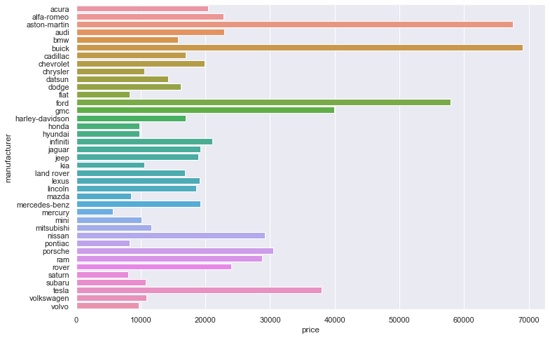

```python
#we are plotting a graph of the average price of the products per manufacturer with a price less than 120000.
sns.set(rc={"figure.figsize":(12, 8)})
sns.barplot(x='price', y='manufacturer',data=manufacturer_price[manufacturer_price.price < 120000], orient='h')
```

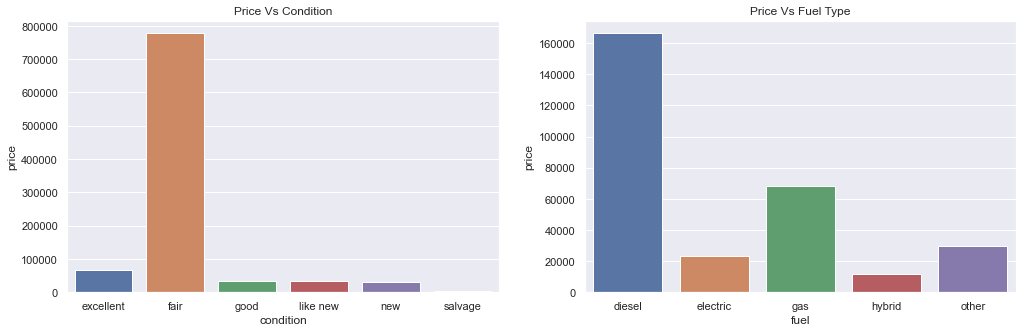

```python
plt.figure(figsize=[17,5])
plt.subplot(1,2,1)
condition_price = new_dataset.groupby('condition', as_index=False)['price'].mean().round()
sns.barplot(condition_price['condition'], condition_price['price'])
plt.title('Price Vs Condition')

plt.subplot(1,2,2)
fuel_price = new_dataset.groupby('fuel', as_index=False)['price'].mean().round()
sns.barplot(fuel_price['fuel'],fuel_price['price'])
plt.title('Price Vs Fuel Type')

plt.show()
```

- It can be observed that the average price in fair condition cars is higher than the excellent,good,like new,new and salvage.
- Price of cars with fuel type of Diesel is higher than electric,gas,hybrid and other.

## Treatment of outliers

- Price column

This is a dataset about used cars, some cars their price are less than 100 dollars others exceed 1000000 dollars due to the fact that there was a registration error. We will filter out the top 1% of the highest prices in the dataset. We create a method of removing outliers from the dataset.

```python
# Let's declare 2 variables that will be equal to the 0.99 and 0.01 percentile of the 'Price' variable
q = new_dataset['price'].quantile(0.99)
v = new_dataset['price'].quantile(0.01)

f_data = new_dataset[(new_dataset['price']>v) & (new_dataset['price']<q)]
```

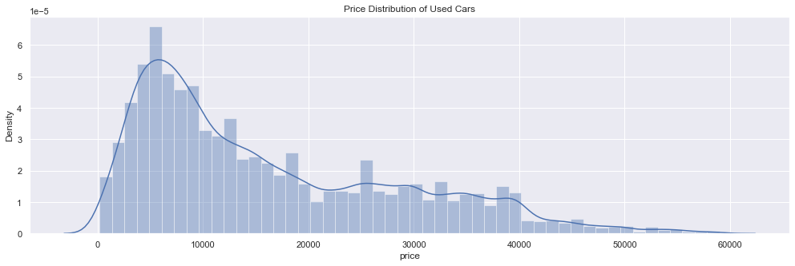

```python
#Check the new values with sns.distplot
plt.figure(figsize=[17,5])
sns.distplot(f_data['price'])
plt.title('Price Distribution of Used Cars')
```

Will do the same for the nex columns (Odemeter and Year).

- Odemeter column

```python
q = f_data['odometer'].quantile(0.99)
s_data = f_data[f_data['odometer']<q]
```

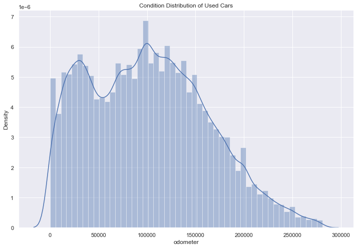

```python
sns.distplot(s_data['odometer'])
plt.title('Condition Distribution of Used Cars')
```

- Year column

```python
q = s_data['year'].quantile(0.01)
t_data = s_data[s_data['year']>q]
```

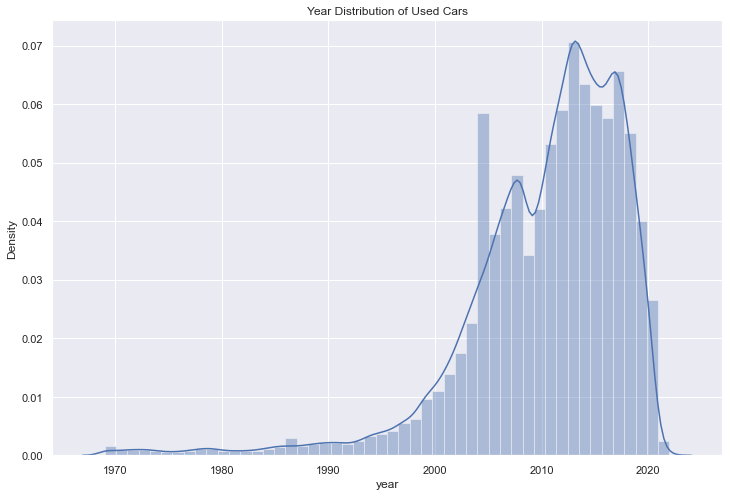

```python
sns.distplot(t_data['year'])
plt.title('Year Distribution of Used Cars')
```

```python
#Reset index
clean_data = t_data.reset_index(drop=True)
#Check again the statistics
clean_data.describe()
```

|  | id | price | year | odometer | lat | long |
| --- | --- | --- | --- | --- | --- | --- |
| count | 1.570250e+05 | 157025.000000 | 157025.000000 | 157025.000000 | 157025.000000 | 157025.000000 |
| mean | 7.311711e+09 | 16294.607056 | 2010.396956 | 102013.409444 | 38.394251 | -92.721091 |
| std | 4.317226e+06 | 12404.121537 | 7.523141 | 61312.870854 | 5.469716 | 17.452201 |
| min | 7.301584e+09 | 200.000000 | 1969.000000 | 1.000000 | -81.838232 | -159.719900 |
| 25% | 7.308519e+09 | 6400.000000 | 2007.000000 | 50996.000000 | 34.830000 | -105.088155 |
| 50% | 7.312918e+09 | 12000.000000 | 2012.000000 | 100000.000000 | 39.160000 | -86.386926 |
| 75% | 7.315347e+09 | 24990.000000 | 2016.000000 | 145000.000000 | 42.244378 | -80.114049 |
| max | 7.317101e+09 | 58999.000000 | 2022.000000 | 280606.000000 | 82.252826 | 139.691700 |

# Scatter plot

The scatter plot will help us to visualize the relationship between price, year, and odometer of the cars in the dataset,also give us insights about the how price, year and odometer are correlated.

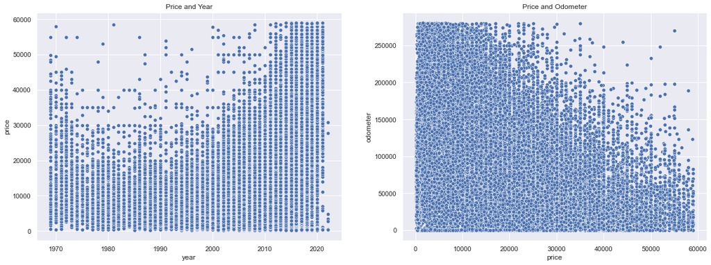

```python
plt.figure(figsize=[20,7])
plt.subplot(1,2,1)
plt.title("Price and Year")
sns.scatterplot(x='year',y='price',data=clean_data)

plt.subplot(1,2,2)
plt.title("Price and Odometer")
sns.scatterplot(x='price',y='odometer',data=clean_data)
```

we can spot patterns but definitely not perfect linear once. we know we should not run a linear regression in this case. we should first transform the variable because the price is not normally distributed.

# Transforming the column 'Price' using log transformation

```python
# Let's transform 'price' with a log transformation
log_price = np.log(clean_data['price'])

# Then we add it to our data frame
clean_data['log_price'] = log_price
clean_data.head(5)
```

|  | id | region | price | year | manufacturer | model | condition | cylinders | fuel | odometer | image_url | description | state | lat | long | posting_date | log_price |
| --- | --- | --- | --- | --- | --- | --- | --- | --- | --- | --- | --- | --- | --- | --- | --- | --- | --- |
| 0 | 7316814884 | auburn | 33590 | 2014 | gmc | sierra 1500 crew cab slt | good | 8 cylinders | gas | 57923 | https://images.craigslist.org/00R0R_lwWjXSEWNa... | Carvana is the safer way to buy a car During t... | al | 32.590 | -85.4800 | 2021-05-04T12:31:18-0500 | 10.421984 |
| 1 | 7316814758 | auburn | 22590 | 2010 | chevrolet | silverado 1500 | good | 8 cylinders | gas | 71229 | https://images.craigslist.org/00R0R_lwWjXSEWNa... | Carvana is the safer way to buy a car During t... | al | 32.590 | -85.4800 | 2021-05-04T12:31:08-0500 | 10.025263 |
| 2 | 7316814989 | auburn | 39590 | 2020 | chevrolet | silverado 1500 crew | good | 8 cylinders | gas | 19160 | https://images.craigslist.org/01212_jjirIWa0y0... | Carvana is the safer way to buy a car During t... | al | 32.590 | -85.4800 | 2021-05-04T12:31:25-0500 | 10.586332 |
| 3 | 7316743432 | auburn | 30990 | 2017 | toyota | tundra double cab sr | good | 8 cylinders | gas | 41124 | https://images.craigslist.org/00x0x_1y9kIOzGCF... | Carvana is the safer way to buy a car During t... | al | 32.590 | -85.4800 | 2021-05-04T10:41:31-0500 | 10.341420 |
| 4 | 7316356412 | auburn | 15000 | 2013 | ford | f-150 xlt | excellent | 6 cylinders | gas | 128000 | https://images.craigslist.org/00404_l4loxHvdQe... | 2013 F-150 XLT V6 4 Door. Good condition. Leve... | al | 32.592 | -85.5189 | 2021-05-03T14:02:03-0500 | 9.615805 |

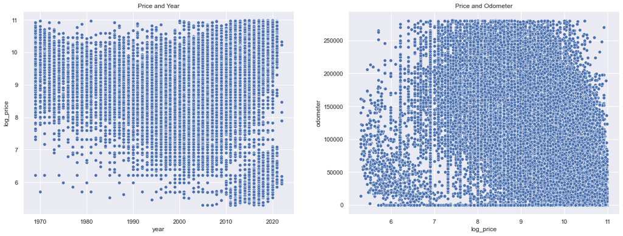

```python
# Let's check the scatters plot
plt.figure(figsize=[20,7])
plt.subplot(1,2,1)
plt.title("Price and Year")
sns.scatterplot(x='year',y='log_price',data=clean_data)

plt.subplot(1,2,2)
plt.title("Price and Odometer")
sns.scatterplot(x='log_price',y='odometer',data=clean_data)
```

```python
# Since we will be using the log price variable, we can drop the old 'Price' column
clean_data = clean_data.drop(['price'],axis=1)
```